# Лабораторная работа 6

## Базовый прогон модели

Создала файл sirpetri_run.jl

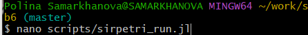

файл

В открывшемся окне вставила код из методички

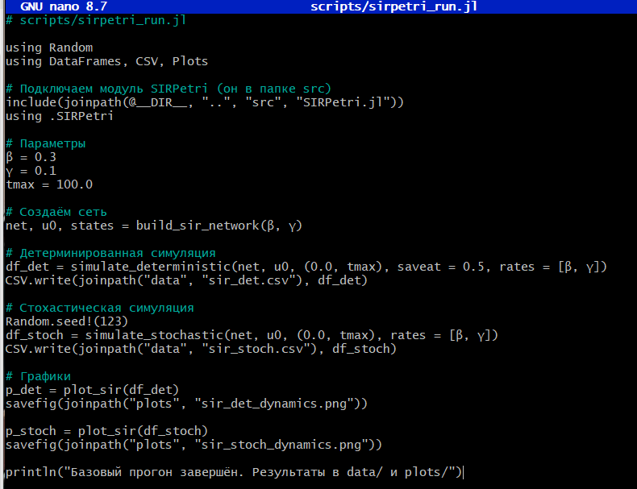

код

Установла необходимые пакеты

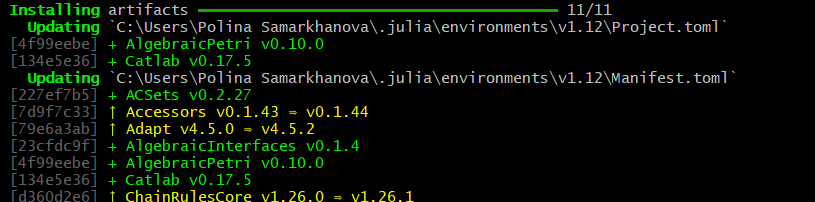

установка пакетов

Запустила код и получила результаты

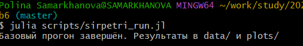

запуск

График det

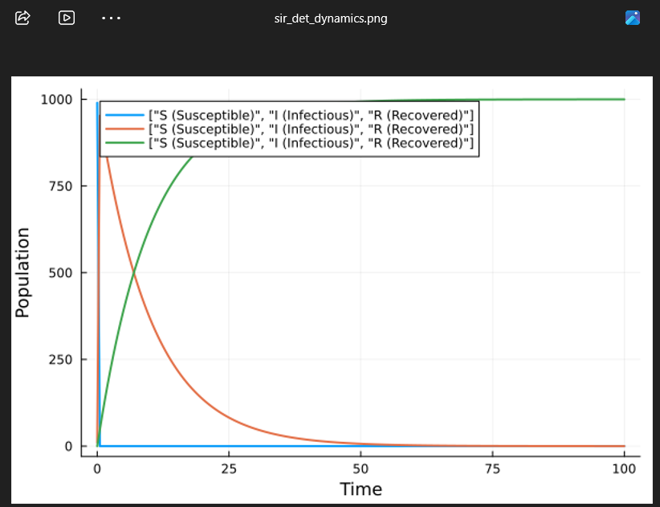

график 1

График stoch

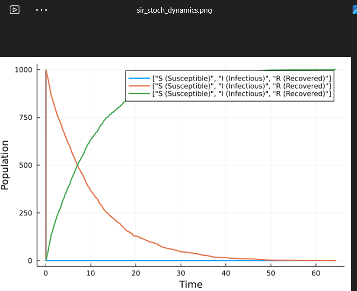

график 2

## Коэффициент заражения β

Создала файл sirpetri_scan_parameters.jl

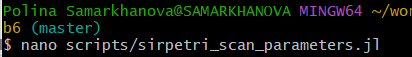

файл

В открывшемся окне вставила код из методички

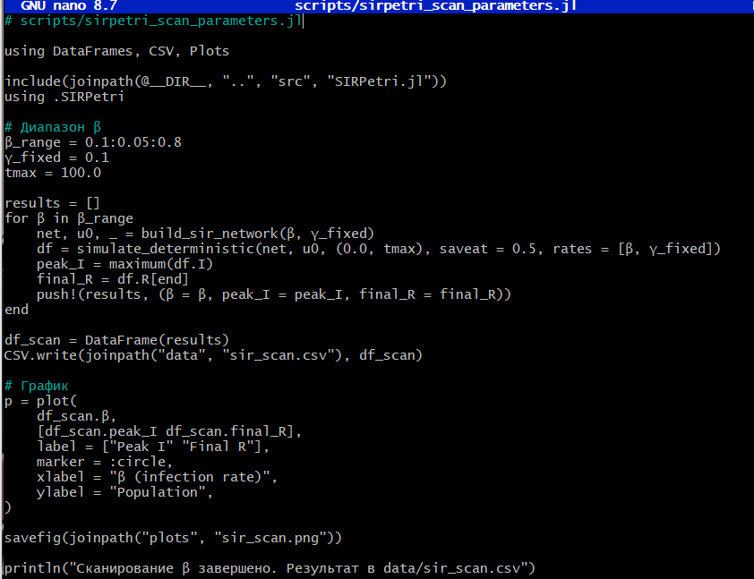

код

Запустила код и получила результат - график

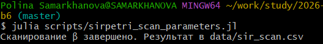

запуск

Просмотр результата

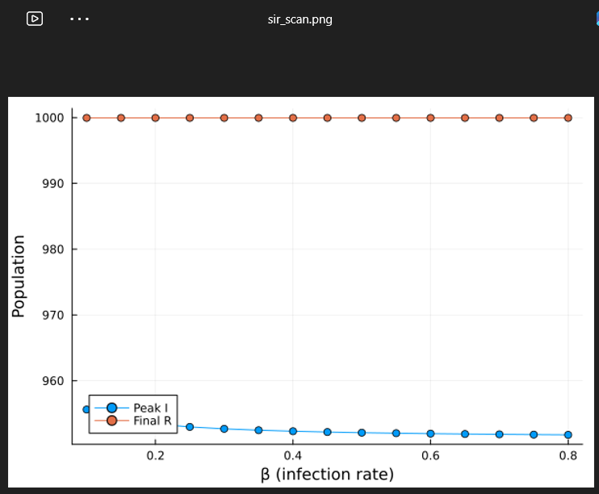

график

## Анимация детерминированной динамики

Создала файл sirpetri_animate.jl

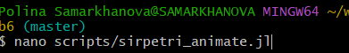

файл

В открывшемся окне вставила код из медодички

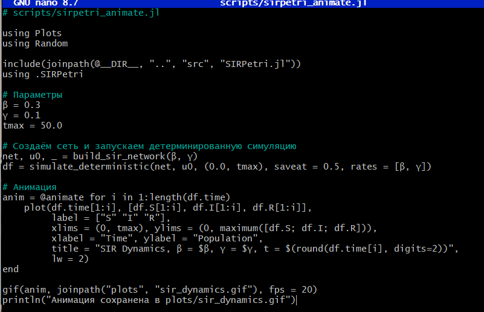

код

Запустила код и получила результат - анимацию

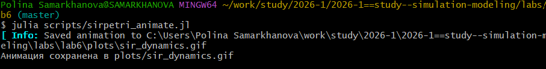

запуск

Открыла анимацию (полное её движение выложено на платформы)

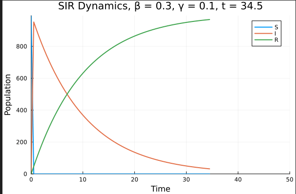

анимация

## Итоговый отчет

Создала файл sirpetri_report.jl

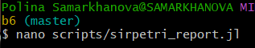

файл

В открывшемся окне вставила код из методички

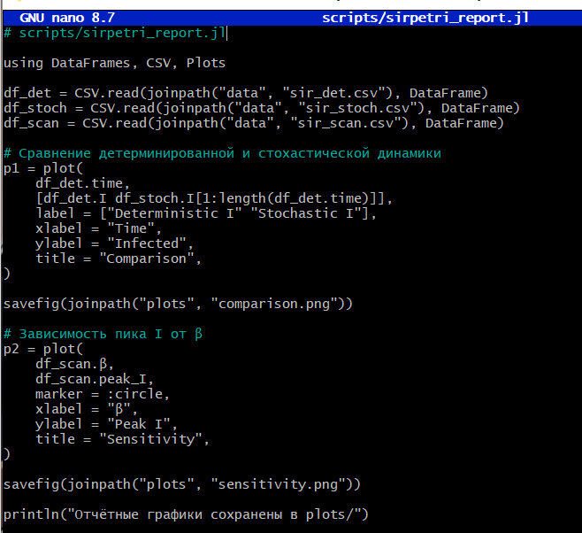

код

Запустила код и получила результаты - графики

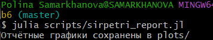

запуск

График comparison

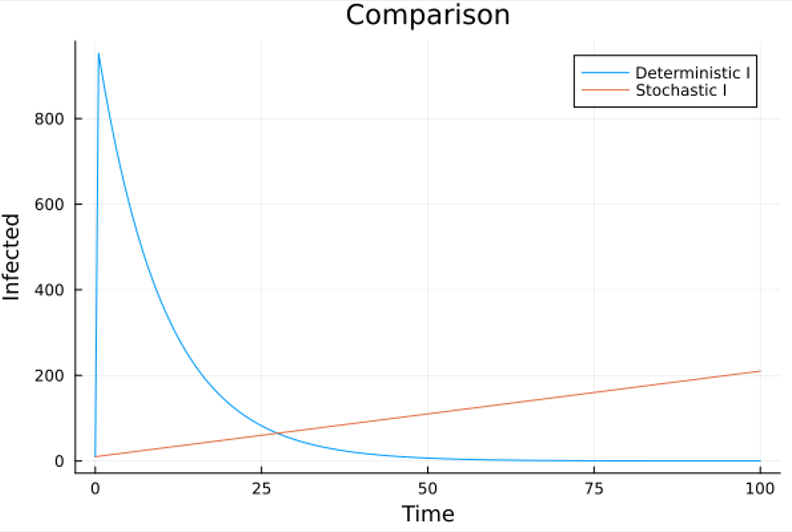

график 1

График sensitivity

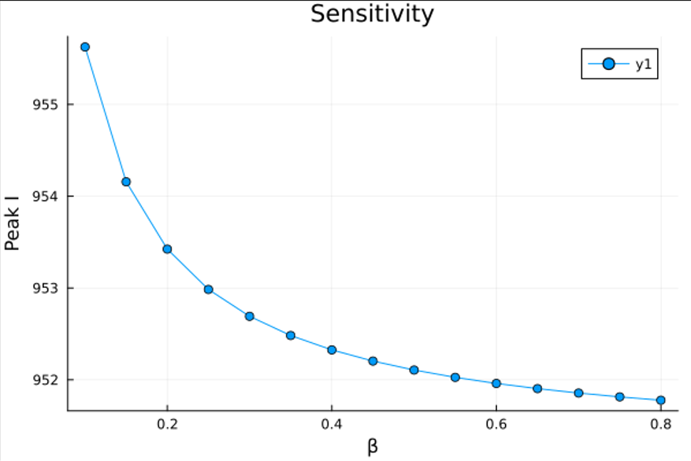

график 2

## Вывод

Спасибо за внимание !